# Integrals

Author

Professor Alex

Published

April 27, 2025

## Introduction

**Topic:** Integrals and the area under a graph  
**Goal:** Understand what an integral is, how it is related to the area under a curve, and how it is used in real life.

Have you ever wondered:

- How can we find the distance a car travels if we know its speed at every moment?
- What does it mean to find the area under a wiggly line?
- How do we calculate the total amount of water flowing through a pipe when the flow rate changes constantly?

These are all questions that can be answered using integrals, one of the fundamental concepts in calculus. In this document, we’ll explore what integrals are, how they work, and how they can be applied to real-world problems.

## What is an Integral?

**Definition:** An *integral* is a mathematical tool used to find the area under a curve on a graph.

### In Plain Language

An integral is like a sophisticated way of adding up lots of small pieces to find a total. Imagine you want to measure the area of a garden with curved edges. You could place a grid over it and count how many square meters are fully inside the garden. For squares that are partially in the garden, you’d have to estimate what fraction of each square is inside.

Integrals work in a similar way, but they use infinitely small pieces, making the calculation exact rather than an estimate.

### From Rectangles to Integrals

Let’s think about calculating the area under a curve:

1. We could divide the area into rectangles.
2. Calculate the area of each rectangle.
3. Add up all those areas to get an approximation.

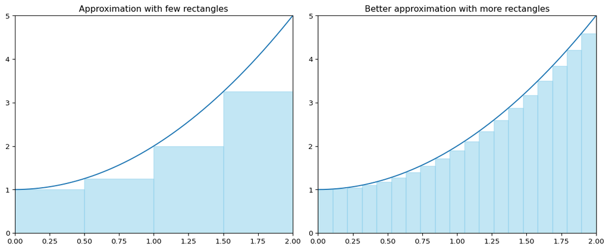

Figure 1: Approximating area under a curve with rectangles

```python
import numpy as np
import matplotlib.pyplot as plt

def f(x):
    return x**2 + 1

x = np.linspace(0, 2, 1000)
y = f(x)

fig, (ax1, ax2) = plt.subplots(1, 2, figsize=(12, 5))

# Few rectangles
x_rect = np.linspace(0, 2, 5)
y_rect = f(x_rect)
width = x_rect[1] - x_rect[0]

ax1.plot(x, y)
ax1.set_xlim(0, 2)
ax1.set_ylim(0, 5)
for i in range(len(x_rect)-1):
    ax1.add_patch(plt.Rectangle((x_rect[i], 0), width, y_rect[i], color='skyblue', alpha=0.5))
ax1.set_title("Approximation with few rectangles")

# Many rectangles
x_rect = np.linspace(0, 2, 20)
y_rect = f(x_rect)
width = x_rect[1] - x_rect[0]

ax2.plot(x, y)
ax2.set_xlim(0, 2)
ax2.set_ylim(0, 5)
for i in range(len(x_rect)-1):
    ax2.add_patch(plt.Rectangle((x_rect[i], 0), width, y_rect[i], color='skyblue', alpha=0.5))
ax2.set_title("Better approximation with more rectangles")

plt.tight_layout()
plt.show()
```

As we make the rectangles narrower and narrower, our approximation gets closer and closer to the exact area. When we use infinitely thin rectangles, we get the exact area, which is what an integral calculates.

### A Real-World Example

If a car’s speed over time is shown on a graph (with time on the x-axis and speed on the y-axis), the total area under the curve represents the total distance traveled.

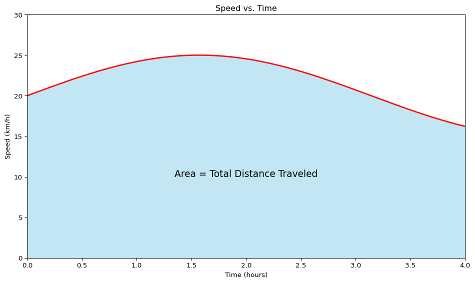

Figure 2: Area under speed-time curve equals distance traveled

```python
import numpy as np
import matplotlib.pyplot as plt
from matplotlib.patches import Polygon

def speed(t):
    return 20 + 5*np.sin(t) # Speed in km/h varying over time

t = np.linspace(0, 4, 1000) # Time in hours
v = speed(t)

fig, ax = plt.subplots(figsize=(10, 6))
ax.plot(t, v, 'r', linewidth=2)
ax.set_xlim(0, 4)
ax.set_ylim(0, 30)
ax.set_xlabel('Time (hours)')
ax.set_ylabel('Speed (km/h)')

# Fill the area under the curve
verts = [(0, 0)] + list(zip(t, v)) + [(4, 0)]
poly = Polygon(verts, facecolor='skyblue', edgecolor='skyblue', alpha=0.5)
ax.add_patch(poly)

ax.text(2, 10, "Area = Total Distance Traveled",
        horizontalalignment='center', fontsize=14)

ax.set_title("Speed vs. Time")
plt.tight_layout()
plt.show()
```

The area under this curve gives us the total distance the car traveled over the 4 hours. Using integration, we can calculate this area exactly.

## Basic Concepts

Before diving deeper into integrals, let’s ensure we understand some key concepts:

### Functions

A **function** is a rule that assigns one output to each input. We often write functions in the form $y = f(x)$, where:

- $x$ is the input (independent variable)
- $f(x)$ is the output (dependent variable)
- $f$ is the rule that transforms the input into the output

For example, the function $f(x) = x^2$ takes any number $x$ and squares it to produce the output.

### Intervals

An **interval** is a range of values that we’re interested in. For integration, we typically use a closed interval $[a, b]$ that includes all values of $x$ from $a$ to $b$, including the endpoints.

For example, $[0, 5]$ represents all values from 0 to 5, including 0 and 5.

### Area Under the Graph

The **area under the graph** refers to the region between:

- The curve represented by the function $f(x)$
- The $x$-axis
- The vertical lines at $x = a$ and $x = b$

This area is what we calculate using a definite integral.

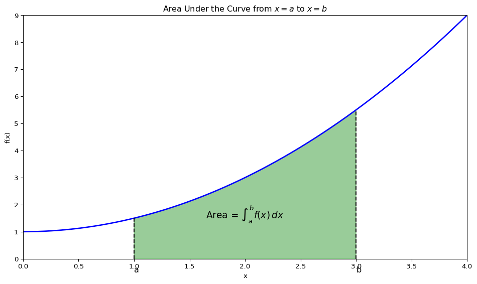

Figure 3: Area under a curve between two points

```python
import numpy as np
import matplotlib.pyplot as plt
from matplotlib.patches import Polygon

def f(x):
    return 0.5*x**2 + 1  # A simple quadratic function

a, b = 1, 3  # Our interval
x = np.linspace(0, 4, 1000)
y = f(x)

fig, ax = plt.subplots(figsize=(10, 6))
ax.plot(x, y, 'b', linewidth=2)
ax.set_xlim(0, 4)
ax.set_ylim(0, f(4))
ax.set_xlabel('x')
ax.set_ylabel('f(x)')

# Fill the area under the curve
ix = np.linspace(a, b)
iy = f(ix)
verts = [(a, 0)] + list(zip(ix, iy)) + [(b, 0)]
poly = Polygon(verts, facecolor='green', edgecolor='green', alpha=0.4)
ax.add_patch(poly)

# Add labels for interval endpoints
ax.plot([a, a], [0, f(a)], 'k--')
ax.plot([b, b], [0, f(b)], 'k--')
ax.text(a, -0.5, 'a', fontsize=12)
ax.text(b, -0.5, 'b', fontsize=12)

ax.text((a+b)/2, f((a+b)/4), "Area = $\\int_a^b f(x) \\, dx$",
        horizontalalignment='center', fontsize=14)

ax.set_title("Area Under the Curve from $x = a$ to $x = b$")
plt.tight_layout()
plt.show()
```

In the context of our earlier car example:

- The function represents the car’s speed at each moment in time
- The interval is the time period we’re interested in
- The area gives us the total distance traveled during that time period

## Formulas

Now let’s introduce the key formulas related to integrals:

### Definite Integral

A **definite integral** gives the exact area under a function $f(x)$ between two points $a$ and $b$:

$$\int_a^b f(x) \, dx$$

The symbols have specific meanings:

- $\int$ is the integration symbol (an elongated S for “sum”)
- $a$ and $b$ are the limits of integration (the interval boundaries)
- $f(x)$ is the function being integrated
- $dx$ indicates that we’re integrating with respect to $x$

### Antiderivative (Indefinite Integral)

An **antiderivative** or **indefinite integral** finds a function whose derivative is the integrand:

$$\int f(x) \, dx = F(x) + C$$

Where:

- $F(x)$ is a function whose derivative equals $f(x)$: $F'(x) = f(x)$
- $C$ is a constant (called the “constant of integration”)

For example, the antiderivative of $f(x) = 2x$ is $F(x) = x^2 + C$

### Fundamental Theorem of Calculus

The **Fundamental Theorem of Calculus** connects antiderivatives with definite integrals:

$$\int_a^b f(x) \, dx = F(b) - F(a)$$

Where $F(x)$ is any antiderivative of $f(x)$.

This theorem is incredibly powerful: it tells us that to find the area under a curve, we can find an antiderivative and evaluate it at the endpoints of our interval.

### Example: Calculate $\int_0^2 (2x) \, dx$

Let’s work through a step-by-step example:

1. Find the antiderivative of $f(x) = 2x$:

   $$F(x) = x^2 + C$$
2. Apply the Fundamental Theorem of Calculus:

   $$\int_0^2 2x \, dx = F(2) - F(0)$$
3. Evaluate $F(x)$ at the endpoints:

   $$F(2) = 2^2 + C = 4 + C$$

   $$F(0) = 0^2 + C = C$$
4. Subtract to find the result:

   $$F(2) - F(0) = (4 + C) - C = 4$$

Therefore, $\int_0^2 2x \, dx = 4$

Let’s verify this visually:

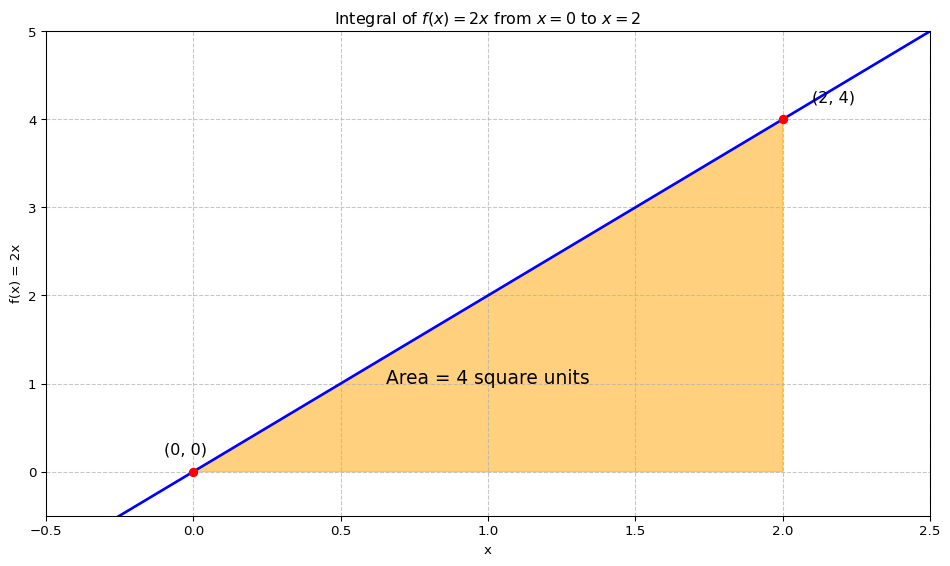

Figure 4: Visualizing the integral of 2x from 0 to 2

```python
import numpy as np
import matplotlib.pyplot as plt
from matplotlib.patches import Polygon

def f(x):
    return 2*x  # Our function f(x) = 2x

a, b = 0, 2  # Integration limits
x = np.linspace(-0.5, 2.5, 1000)
y = f(x)

fig, ax = plt.subplots(figsize=(10, 6))
ax.plot(x, y, 'b', linewidth=2)
ax.set_xlim(-0.5, 2.5)
ax.set_ylim(-0.5, 5)
ax.set_xlabel('x')
ax.set_ylabel('f(x) = 2x')
ax.grid(True, linestyle='--', alpha=0.7)

# Fill the area under the curve
ix = np.linspace(a, b)
iy = f(ix)
verts = [(a, 0)] + list(zip(ix, iy)) + [(b, 0)]
poly = Polygon(verts, facecolor='orange', edgecolor='orange', alpha=0.5)
ax.add_patch(poly)

# Mark the area
ax.text(1, 1, "Area = 4 square units",
        horizontalalignment='center', fontsize=14)

# Add coordinate points
ax.plot(a, f(a), 'ro')
ax.plot(b, f(b), 'ro')
ax.text(a-0.1, f(a)+0.2, f'({a}, {f(a)})', fontsize=12)
ax.text(b+0.1, f(b)+0.2, f'({b}, {f(b)})', fontsize=12)

ax.set_title("Integral of $f(x) = 2x$ from $x = 0$ to $x = 2$")
plt.tight_layout()
plt.show()
```

The area under this line forms a triangle with base 2 and height 4, giving an area of $\frac{1}{2} \times 2 \times 4 = 4$ square units, which matches our calculation.

## Real-Life Applications of Integrals

Integrals are not just abstract mathematical concepts; they have numerous practical applications across various fields. Let’s explore some of them:

### Physics Applications

#### Distance from Speed

If you know a vehicle’s speed $v(t)$ at each moment in time, the total distance traveled is:

$$d = \int_{t_1}^{t_2} v(t) \, dt$$

This is our car example from earlier.

#### Work Done by a Variable Force

When a force $F(x)$ varies with position, the work done is:

$$W = \int_{x_1}^{x_2} F(x) \, dx$$

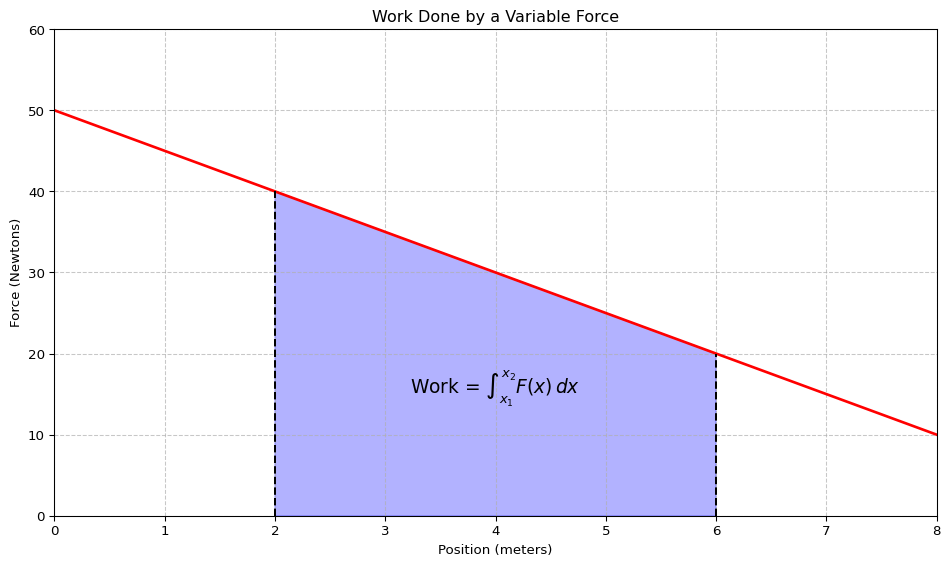

Figure 5: Work done by a variable force

```python
import numpy as np
import matplotlib.pyplot as plt
from matplotlib.patches import Polygon

def force(x):
    return 50 - 5*x  # A decreasing force (in Newtons)

x = np.linspace(0, 8, 1000)  # Position (in meters)
f = force(x)

fig, ax = plt.subplots(figsize=(10, 6))
ax.plot(x, f, 'r', linewidth=2)
ax.set_xlim(0, 8)
ax.set_ylim(0, 60)
ax.set_xlabel('Position (meters)')
ax.set_ylabel('Force (Newtons)')
ax.grid(True, linestyle='--', alpha=0.7)

# Fill the area under the curve from x=2 to x=6
a, b = 2, 6
ix = np.linspace(a, b)
iy = force(ix)
verts = [(a, 0)] + list(zip(ix, iy)) + [(b, 0)]
poly = Polygon(verts, facecolor='blue', edgecolor='blue', alpha=0.3)
ax.add_patch(poly)

# Annotate
ax.text(4, 15, "Work = $\\int_{x_1}^{x_2} F(x) \\, dx$",
        horizontalalignment='center', fontsize=14)
ax.plot([a, a], [0, force(a)], 'k--')
ax.plot([b, b], [0, force(b)], 'k--')

ax.set_title("Work Done by a Variable Force")
plt.tight_layout()
plt.show()
```

### Economics Applications

#### Total Revenue over Time

If a company’s revenue rate $R(t)$ changes over time, the total revenue is:

$$\text{Total Revenue} = \int_{t_1}^{t_2} R(t) \, dt$$

#### Consumer and Producer Surplus

In economics, the consumer surplus (benefit consumers receive above what they pay) is calculated as the area between the demand curve and the price line.

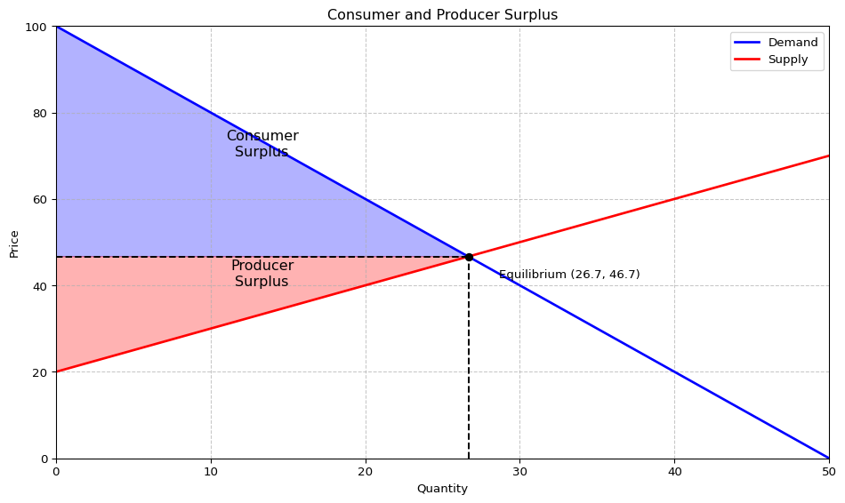

Figure 6: Consumer and producer surplus in economics

```python
import numpy as np
import matplotlib.pyplot as plt
from matplotlib.patches import Polygon

def demand(q):
    return 100 - 2*q  # Demand curve: price as a function of quantity

def supply(q):
    return 20 + q  # Supply curve: price as a function of quantity

q = np.linspace(0, 50, 1000)
p_demand = demand(q)
p_supply = supply(q)

# Find equilibrium (where demand = supply)
# 100 - 2q = 20 + q
# 80 = 3q
# q = 26.67
q_equilibrium = 80/3
p_equilibrium = demand(q_equilibrium)  # or supply(q_equilibrium)

fig, ax = plt.subplots(figsize=(10, 6))
ax.plot(q, p_demand, 'b', linewidth=2, label='Demand')
ax.plot(q, p_supply, 'r', linewidth=2, label='Supply')
ax.set_xlim(0, 50)
ax.set_ylim(0, 100)
ax.set_xlabel('Quantity')
ax.set_ylabel('Price')
ax.grid(True, linestyle='--', alpha=0.7)
ax.legend()

# Mark equilibrium
ax.plot([q_equilibrium, q_equilibrium], [0, p_equilibrium], 'k--')
ax.plot([0, q_equilibrium], [p_equilibrium, p_equilibrium], 'k--')
ax.plot(q_equilibrium, p_equilibrium, 'ko')
ax.text(q_equilibrium+2, p_equilibrium-5, f'Equilibrium ({q_equilibrium:.1f}, {p_equilibrium:.1f})', fontsize=10)

# Consumer surplus (area between demand curve and equilibrium price)
iq = np.linspace(0, q_equilibrium)
ip_demand = demand(iq)
verts = [(0, p_equilibrium)] + list(zip(iq, ip_demand)) + [(q_equilibrium, p_equilibrium)]
poly = Polygon(verts, facecolor='blue', edgecolor='blue', alpha=0.3)
ax.add_patch(poly)
ax.text(q_equilibrium/2, 70, "Consumer\nSurplus",
        horizontalalignment='center', fontsize=12)

# Producer surplus (area between equilibrium price and supply curve)
iq = np.linspace(0, q_equilibrium)
ip_supply = supply(iq)
verts = [(0, p_equilibrium)] + [(q_equilibrium, p_equilibrium)] + list(zip(iq[::-1], ip_supply[::-1]))
poly = Polygon(verts, facecolor='red', edgecolor='red', alpha=0.3)
ax.add_patch(poly)
ax.text(q_equilibrium/2, 40, "Producer\nSurplus",
        horizontalalignment='center', fontsize=12)

ax.set_title("Consumer and Producer Surplus")
plt.tight_layout()
plt.show()
```

### Biology/Medicine Applications

#### Blood Flow Volume

If we know the blood flow rate $r(t)$ through an artery over time, the total volume of blood is:

$$V = \int_{t_1}^{t_2} r(t) \, dt$$

#### Drug Concentration

The total amount of a drug in the bloodstream can be calculated by integrating the concentration function over time.

### Engineering Applications

#### Material Usage

Engineers use integrals to calculate:

- Volume of complex shapes: $V = \int_{a}^{b} A(x) \, dx$ where $A(x)$ is the cross-sectional area
- Surface area of curved structures
- Mass of objects with varying density

#### Heat Transfer

The total heat transferred through a material over time is found using integration.

In all these applications, the core idea is the same: we’re summing up infinitesimally small contributions to find a total amount. This demonstrates the power and versatility of integrals in solving real-world problems.

## Real-Life Example

Let’s walk through a complete real-life example to demonstrate how integrals are used in practice.

### Scenario: Estimating Fuel Usage of a Car

Imagine you’re driving on a trip and want to estimate how much fuel your car will use. The fuel consumption rate varies depending on your speed and road conditions.

Let’s say the fuel consumption rate (in liters per hour) is given by the function:

$$f(t) = 3 + 0.5\sin(t) + 0.2t$$

Where $t$ is the time in hours since you started driving.

### Step 1: Understand what we’re calculating

We want to find the total fuel used over a 4-hour journey. Since fuel consumption rate is given in liters per hour, we need to find:

$$\text{Total Fuel} = \int_{0}^{4} f(t) \, dt$$

### Step 2: Visualize the consumption rate

First, let’s see how the fuel consumption rate changes over time:

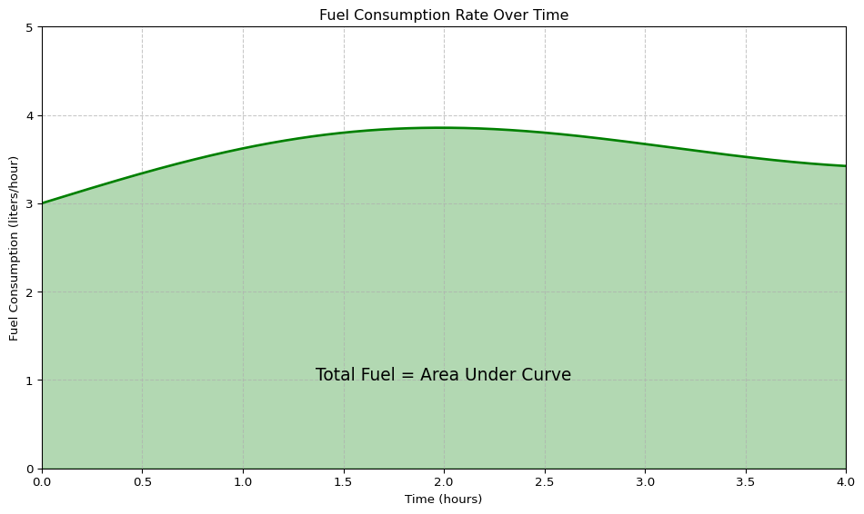

Figure 7: Fuel consumption rate over time

```python
import numpy as np
import matplotlib.pyplot as plt
from matplotlib.patches import Polygon

def fuel_rate(t):
    return 3 + 0.5*np.sin(t) + 0.2*t  # Fuel consumption in liters/hour

t = np.linspace(0, 4, 1000)  # Time in hours
rate = fuel_rate(t)

fig, ax = plt.subplots(figsize=(10, 6))
ax.plot(t, rate, 'g', linewidth=2)
ax.set_xlim(0, 4)
ax.set_ylim(0, 5)
ax.set_xlabel('Time (hours)')
ax.set_ylabel('Fuel Consumption (liters/hour)')
ax.grid(True, linestyle='--', alpha=0.7)

# Fill the area under the curve
verts = [(0, 0)] + list(zip(t, rate)) + [(4, 0)]
poly = Polygon(verts, facecolor='green', edgecolor='green', alpha=0.3)
ax.add_patch(poly)

ax.text(2, 1, "Total Fuel = Area Under Curve",
        horizontalalignment='center', fontsize=14)

ax.set_title("Fuel Consumption Rate Over Time")
plt.tight_layout()
plt.show()
```

### Step 3: Calculate the integral

To find the total fuel used, we need to integrate the fuel rate function over the 4-hour journey.

For this function $f(t) = 3 + 0.5\sin(t) + 0.2t$, we can find the antiderivative:

$$F(t) = 3t - 0.5\cos(t) + 0.1t^2 + C$$

Now we can apply the Fundamental Theorem of Calculus:

$$\int_{0}^{4} f(t) \, dt = F(4) - F(0)$$

Let’s compute $F(4)$ and $F(0)$:

$$F(4) = 3(4) - 0.5\cos(4) + 0.1(4)^2 + C = 12 - 0.5\cos(4) + 1.6 + C$$

$$F(0) = 3(0) - 0.5\cos(0) + 0.1(0)^2 + C = 0 - 0.5(1) + 0 + C = -0.5 + C$$

Therefore:

$$F(4) - F(0) = [12 - 0.5\cos(4) + 1.6 + C] - [-0.5 + C]$$

$$= 12 - 0.5\cos(4) + 1.6 + 0.5$$

$$= 14.1 - 0.5\cos(4)$$

Since $\cos(4) \approx -0.654$, we get:

$$F(4) - F(0) \approx 14.1 - 0.5(-0.654) \approx 14.1 + 0.327 \approx 14.427$$

```python
import numpy as np
from scipy import integrate

def fuel_rate(t):
    return 3 + 0.5*np.sin(t) + 0.2*t

# Calculate the integral numerically
total_fuel, error = integrate.quad(fuel_rate, a=0, b=4)

print(f"Total fuel consumed over 4 hours: {total_fuel:.3f} liters")
```

```
Total fuel consumed over 4 hours: 14.427 liters
```

### Step 4: Interpret the result

Our calculation shows that over the 4-hour journey, the car will use approximately 14.43 liters of fuel.

## Python Implementation Example

Let’s implement a complete example of calculating and visualizing an integral using Python. We’ll use the libraries `scipy.integrate` for numerical integration and `matplotlib` for visualization.

### Problem Statement

Let’s work with a speed function $v(t) = 3t^2 + 2t + 1$ that represents the speed of a vehicle (in meters per second) at time $t$ (in seconds).

We want to:

1. Define this function in Python
2. Calculate the total distance traveled over the interval [0, 5]
3. Plot the function and visualize the area under the curve

### Step 1: Import necessary libraries

```python
import numpy as np
from scipy import integrate
import matplotlib.pyplot as plt
from matplotlib.patches import Polygon
```

### Step 2: Define the function

```python
def speed(t):
    """Vehicle speed (m/s) as a function of time (s)."""
    return 3*t**2 + 2*t + 1
```

### Step 3: Set up the integration interval

```python
# Time interval from 0 to 5 seconds
t_start = 0
t_end = 5
```

### Step 4: Numerically integrate the function

We’ll use `scipy.integrate.quad` which returns both the integral value and an error estimate:

```python
# Calculate total distance
total_distance, error = integrate.quad(speed, t_start, t_end)

print(f"Total distance traveled: {total_distance:.2f} meters")
print(f"Estimated error: {error:.2e}")
```

```
Total distance traveled: 155.00 meters
Estimated error: 1.72e-12
```

### Step 5: Plot the function and visualize the area

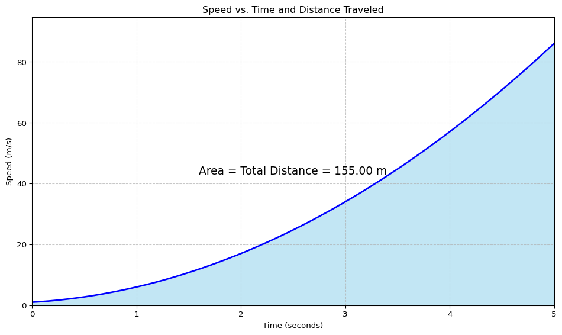

Figure 8: Visualizing the integral of v(t) from 0 to 5

```python
# Generate points for plotting
t = np.linspace(t_start, t_end, 1000)
v = speed(t)

# Create the figure
fig, ax = plt.subplots(figsize=(10, 6))

# Plot the speed function
ax.plot(t, v, 'b', linewidth=2)
ax.set_xlim(t_start, t_end)
ax.set_ylim(0, max(v)*1.1)
ax.set_xlabel('Time (seconds)')
ax.set_ylabel('Speed (m/s)')
ax.grid(True, linestyle='--', alpha=0.7)

# Fill the area under the curve
verts = [(t_start, 0)] + list(zip(t, v)) + [(t_end, 0)]
poly = Polygon(verts, facecolor='skyblue', edgecolor='skyblue', alpha=0.5)
ax.add_patch(poly)

# Annotate with the calculated distance
ax.text((t_start + t_end)/2, max(v)/2,
        f"Area = Total Distance = {total_distance:.2f} m",
        horizontalalignment='center', fontsize=14)

ax.set_title("Speed vs. Time and Distance Traveled")
plt.tight_layout()
plt.show()
```

### Step 6: Verify the result with an analytical solution

For the function $v(t) = 3t^2 + 2t + 1$, the antiderivative is $V(t) = t^3 + t^2 + t + C$.

Using the Fundamental Theorem of Calculus:

- $\int_0^5 (3t^2 + 2t + 1) \, dt = V(5) - V(0)$
- $= (5^3 + 5^2 + 5) - (0^3 + 0^2 + 0)$
- $= (125 + 25 + 5) - 0$
- $= 155$

Let’s verify this matches our numerical result:

```python
def antiderivative(t):
    """Antiderivative of the speed function."""
    return t**3 + t**2 + t

analytical_result = antiderivative(t_end) - antiderivative(t_start)
print(f"Analytical result: {analytical_result}")
print(f"Difference between numerical and analytical: {abs(total_distance - analytical_result):.2e}")
```

```
Analytical result: 155
Difference between numerical and analytical: 2.84e-14
```

The numerical and analytical results match closely, confirming our integration.

### Understanding the Code

Let’s break down the key components of our implementation:

1. **Function Definition**:

   ```python
   def speed(t):
       return 3*t**2 + 2*t + 1
   ```

   This creates a Python function that calculates the speed at any time `t`.
2. **Numerical Integration**:

   ```python
   total_distance, error = integrate.quad(speed, t_start, t_end)
   ```

   The `quad` function takes:
   - The function to integrate (`speed`)
   - Lower limit (`t_start`)
   - Upper limit (`t_end`)

   It returns the integral value and an error estimate.
3. **Plotting with `matplotlib`**:

   ```python
   ax.plot(t, v, 'b', linewidth=2)
   ```

   This plots the speed function using a blue line.
4. **Visualizing the Area**:

   ```python
   verts = [(t_start, 0)] + list(zip(t, v)) + [(t_end, 0)]
   poly = Polygon(verts, facecolor='skyblue', alpha=0.5)
   ```

   This creates a polygon that represents the area under the curve and fills it with a semi-transparent blue color.

This example demonstrates how to effectively use Python to perform and visualize integrations, which is a common task in scientific computing, data analysis, and engineering applications.

## Conclusion

### Key Points Summary

Throughout this document, we’ve explored integrals and their significance in mathematics and real-world applications:

1. **Integrals calculate areas under curves**
   - They provide exact measures where approximations with rectangles would be inexact
   - They work by adding up infinitely many infinitesimally small pieces
2. **The Fundamental Theorem of Calculus**
   - Connects integration (finding areas) with differentiation (finding slopes)
   - Allows us to calculate definite integrals using antiderivatives
   - Expressed as: $\int_a^b f(x) \, dx = F(b) - F(a)$ where $F'(x) = f(x)$
3. **Practical applications span across disciplines**
   - Physics: distance, work, energy
   - Economics: total cost, revenue, consumer surplus
   - Biology: fluid flow, drug concentration
   - Engineering: material usage, heat transfer
4. **Computational tools make integration accessible**
   - Python libraries like SciPy and Matplotlib allow for numerical integration and visualization
   - These tools enable us to solve real-world problems that don’t have simple analytical solutions

### Beyond The Basics

As you continue your mathematical journey, you’ll discover that integration extends far beyond what we’ve covered:

- **Multiple integrals** allow calculation of volumes and higher-dimensional quantities
- **Line integrals** calculate quantities along paths in space
- **Surface integrals** work with quantities distributed across surfaces
- **Techniques** like integration by parts, substitution, and partial fractions help solve complex integrals

### Integration and Differentiation: Two Sides of the Same Coin

One of the most beautiful aspects of calculus is how differentiation and integration are inverse operations:

- Differentiation breaks things down into infinitesimal rates of change
- Integration builds things up by adding infinitesimal pieces

This duality, formalized in the Fundamental Theorem of Calculus, represents one of the most profound connections in mathematics.

### Closing Thoughts

Integrals aren’t just abstract mathematical concepts—they’re powerful tools that help us understand and solve real problems in our world. Whether calculating a car’s travel distance, estimating fuel consumption, or analyzing economic trends, integration provides a framework for moving from knowing how things change (rates) to understanding total effects (accumulations).

As you encounter situations involving accumulation or totals of varying quantities, remember that integration is likely the mathematical tool you need. The ability to think in terms of integrals will serve you well across numerous fields and applications.

> “Mathematics is the art of giving the same name to different things.” — Henri Poincaré

In integration, we see this truth clearly: whether we’re adding up distances, volumes, revenues, or any other quantity that accumulates, the integral provides a unified approach to solving these seemingly different problems.